# AS08_Web-Scraping-HTML_ref

曾子軒 Teaching Assistant

2022/05/19

### 題目說明

這份作業希望能夠讓你熟悉 Web Scraping 的流程，這週的重點會著重在 html。

## A. scrape appledaily foundation（50分）

本次作業的案例為[蘋果基金會的捐款平台](https://tw.feature.appledaily.com/charity/projlist/1)，請抓取捐款案的最近 10 頁資料，並整理出 2 個 dataframe，且分為以下欄位： - df_case_list，包含捐款案id(case_id)、新聞標題(title)、捐款案時間(date)、捐款案狀態(status)、捐款總額(amount)、新聞連結(link)、捐款明細連結(link_detail)  
- df_case_donation，包含捐款案id(case_id)、捐款明細連結(link_detail)、捐款者(donator)、捐款金額(donation)、捐款時間(donate_date)

另外，請注意以下幾點 - 請去掉下方程式碼的註解(檢查部分) 以驗證你所抓到的資料未有重複 - 用橫向 bar chart 印出捐款次數最多的前十大單位或個體（注意，個體可能是以全形或半形逗號分隔。先不處理填錯名字的問題、也暫時不考慮如「XXX全家」的問題） - 請用 `glimpse()` 分別呈現上述 tibble 的長相

### 作答區 - 爬蟲程式碼

```r
### your code
library(tidyverse)
# library(httr)
# library(rvest)
#
# p_read_html <- possibly(read_html, otherwise = NULL)
#
# ##### 抓案例
# df_case_list <- tibble()
# for(i in 1:10){
#   url <- str_c("https://tw.feature.appledaily.com/charity/projlist/", i)
#   html <- url %>% curl::curl(handle = curl::new_handle("useragent" = "Mozilla/5.0")) %>% p_read_html()
#   table <- html %>% html_table()
#   df_table <-
#     table[[1]] %>% as_tibble() %>% slice(-1) %>% `colnames<-`(c("case_id", "title", "date", "status", "amount", "detail"))
#
#   link <- html %>% html_nodes(".artcatdetails") %>% html_attr("href")
#   link_detail <- html %>% html_nodes(".details") %>% html_attr("href")
#   df_case_list_tmp <- df_table %>% bind_cols(tibble(link = link, link_detail = link_detail))
#
#   df_case_list <- df_case_list %>% bind_rows(df_case_list_tmp)
#   print(i)
#   Sys.sleep(20)
# }
#
# df_case_list
# df_case_list %>% distinct(case_id)
# df_case_list %>% write_rds("data/AS08/df_case_list.rds")
# df_case_list %>% write_csv("data/AS08/df_case_list.csv")
#
# ##### 抓捐款清單
# df_case_donation <- tibble()
# index_now <- 1
# index_length <- ceiling(dim(df_case_list)[1]/10)
#
# for(i in index_now:index_length){
#   j = i*10-9
#   k = j+9
#   url = df_case_list %>% select(link_detail) %>% slice(j:k) %>% pull()
#
#   html = url %>% map(function(x){x %>% curl::curl(handle = curl::new_handle("useragent" = "Mozilla/5.0")) %>% p_read_html()}) %>%
#     set_names(url) %>% compact()
#   html_index <- html %>%
#     map(function(x){x %>% html_nodes(".addellis-f") %>% html_text() %>% '['(1)}) %>%
#     map_lgl(function(x){!is.na(x)})
#
#   html_f <- html[html_index]
#
#   if(length(html_f)==0) {index_now = index_now + 1;print(str_c("all links are dead: article ",j, " to article ", k));next}
#
#   table_raw <- html_f %>% map(function(x){x %>% html_table()})
#   df_case_donation_tmp <- table_raw %>% map(function(x){x %>% '[['(2) %>% slice(-1)}) %>% bind_rows(.id = "link_detail") %>% as_tibble() %>%
#     `colnames<-`(c("link_detail","donator_order", "donator", "donation", "donate_date"))
#
#   df_case_donation <- df_case_donation %>% bind_rows(df_case_donation_tmp)
#
#   print(str_c("finished article ", j, " to article ", k))
#   index_now = index_now + 1
#   Sys.sleep(20)
#   closeAllConnections()
#   gc()
# }
#
# df_case_donation
# df_case_donation %>% distinct(link_detail)
# df_case_donation %>% count(link_detail)
# df_case_donation %>%
#   mutate(case_id = str_remove(link_detail, "https://tw.feature.appledaily.com/charity/projdetail/")) %>%
#   write_rds("data/AS08/df_case_donation.rds")
# df_case_donation %>%
#   mutate(case_id = str_remove(link_detail, "https://tw.feature.appledaily.com/charity/projdetail/")) %>%
#   write_csv("data/AS08/df_case_donation.csv")

# df_case_donation <- read_csv("data/AS08/df_case_donation.csv")
# df_case_list <- read_csv("data/AS08/df_case_list.csv")
```

### 作答區 - 作業要求檢查

這邊的 code 請去掉 comment 後執行喔！可以用來確認結果！

```r
### your code
df_case_list <- read_csv("data/AS08/df_case_list.csv")
df_case_donation <- read_csv("data/AS08/df_case_donation.csv")

## 檢查
df_case_list %>% summarise(n_distinct(case_id))
```

```
#> # A tibble: 1 × 1
#>   `n_distinct(case_id)`
#>                   <int>
#> 1                   200
```

```r
df_case_list %>% summarise(n_distinct(link))
```

```
#> # A tibble: 1 × 1
#>   `n_distinct(link)`
#>                <int>
#> 1                200
```

```r
df_case_list %>% summarise(n_distinct(link_detail))
```

```
#> # A tibble: 1 × 1
#>   `n_distinct(link_detail)`
#>                       <int>
#> 1                       200
```

```r
df_case_donation %>% summarise(n_distinct(link_detail))
```

```
#> # A tibble: 1 × 1
#>   `n_distinct(link_detail)`
#>                       <int>
#> 1                       190
```

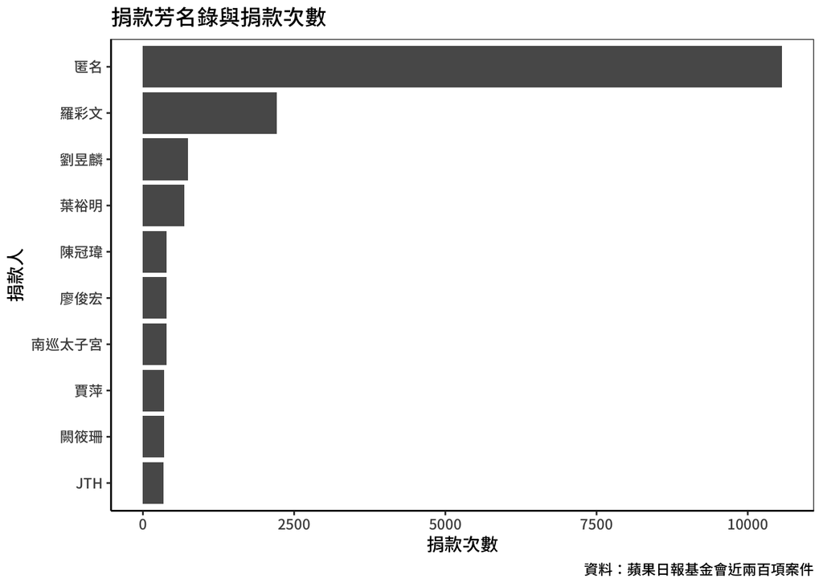

```r
## bar chart
df_donator_top <- df_case_donation %>%
  mutate(donator = str_split(donator, ",|，|、")) %>%
  unnest(c(donator)) %>%
  mutate(donator = if_else(str_detect(donator, "善心|匿名|不具名|無"), "匿名", donator)) %>%
  count(donator, sort = T) %>% head(20)

df_donator_top %>% slice(1:10) %>% mutate(donator = fct_reorder(donator, n)) %>%
  ggplot(aes(donator, n)) + geom_col() +
  coord_flip() +
  theme_bw() +
  guides(fill = FALSE) +
  labs(x= "捐款人",y= "捐款次數", title = "捐款芳名錄與捐款次數", caption = "資料：蘋果日報基金會近兩百項案件") +
  theme(panel.grid.major = element_blank(), panel.grid.minor = element_blank(),
        panel.background = element_blank(), axis.line = element_line(colour = "black")) +
  theme(text = element_text(family = "Noto Sans CJK TC Medium"))
```

```r
## 看長相
df_case_list %>% glimpse()
```

```
#> Rows: 200
#> Columns: 8
#> $ case_id     <chr> "A5331", "A5330", "A5329", "A5328", "A5327", "A5326", "A53…
#> $ title       <chr> "男顧憨兒女未料罹雙癌　憂若先走「他們怎麼辦 」", "妻心疼癌…
#> $ date        <date> 2022-05-09, 2022-05-06, 2022-05-05, 2022-05-04, 2022-04-2…
#> $ status      <chr> "未結案", "未結案", "未結案", "未結案", "未結案", "未結案"…
#> $ amount      <dbl> 16989, 216216, 243709, 287432, 890815, 516595, 702862, 690…
#> $ detail      <chr> "明細", "明細", "明細", "明細", "明細", "明細", "明細", "…
#> $ link        <chr> "https://tw.appledaily.com/life/20220509/TUHVZIFISVBHDLXGL…
#> $ link_detail <chr> "https://tw.feature.appledaily.com/charity/projdetail/A533…
```

```r
df_case_donation %>% glimpse()
```

```
#> Rows: 297,266
#> Columns: 6
#> $ link_detail   <chr> "https://tw.feature.appledaily.com/charity/projdetail/A5…
#> $ donator_order <dbl> 1, 2, 3, 4, 5, 6, 7, 8, 9, 10, 11, 12, 13, 14, 15, 16, 1…
#> $ donator       <chr> "明新鞋行", "智懋工程有限公司", "吳奈奈子", "姚仲澤", "…
#> $ donation      <dbl> 30000, 20000, 20000, 20000, 20000, 12000, 11000, 11000, …
#> $ donate_date   <date> 2021-11-23, 2021-11-22, 2021-11-27, 2021-11-27, 2021-12…
#> $ case_id       <chr> "A5240", "A5240", "A5240", "A5240", "A5240", "A5240", "A…
```

## B. scrape PTT（50分）

本小題的案例為[PTT 感情版]https://www.ptt.cc/bbs/Boy-Girl/index.html)，請抓取最近 5 頁的文章列表（20篇/頁），再抓取每篇文章的內文與留言，並整理出 3 個 dataframe，且分為以下欄位：

- df_index，包含作者(index_author)、標題(index_title)、連結(index_link)
- df_article，包含作者(article_author)、標題(article_title)、時間(article_dt)、內文(article_text)、IP與國家(article_IP)、留言數(article_ncomments)、連結(index_link)
- df_comment，包含推文作者(comment_author)、推文時間(comment_dt)、推文內容(comment_text)、推文推噓(comment_type)、連結(index_link)

另外，請注意以下幾點

- 請去掉下方程式碼的註解(檢查部分)，以驗證你所抓到的資料未有重複
- 請用 `glimpse()` 分別呈現上述 tibble 的長相
- 請把文章(df_article)和留言(df_comment)串在一起

### 作答區 - 爬蟲程式碼

你可以把結果匯出成 csv，這樣就不用每次 knit 都要重抓一次資料，不過爬蟲的 code 要留著喔！加上 # comment 就好。

```r
### your code
library(tidyverse)

# df_index %>% write_csv("data/AS08/df_index.csv")
# df_article %>% write_csv("data/AS08/df_article.csv")
# df_comment %>% write_csv("data/AS08/df_comment.csv")
```

### 作答區 - 作業要求檢查

```r
### your code
# df_index <- read_csv("data/AS08/df_index.csv")
# df_article <- read_csv("data/AS08/df_article.csv")
# df_comment <- read_csv("data/AS08/df_comment.csv")
#
# # 檢查部分!!! 請去掉!!!
# df_index %>% summarise(n_distinct(index_link))
# df_article %>% summarise(n_distinct(index_link))
# df_comment %>% summarise(n_distinct(index_link))
#
#
# # 看長相
# df_index %>% glimpse()
# df_article %>% glimpse()
# df_comment %>% glimpse()

### your code - 串在一起
```